# The basics of R

# Data Import

Of course, no one expects you to enter all of your data in R by hand. When you have data, it’s usually in tabular format. In this example, we’ll use data from the *agricolae* package assessing potato varieties for resistance to late blight in locations in Peru (see `help("ComasOxapampa", package = "agricolae")` for details)

To read these data into R, you can use `read.table()`:

```r
> ComasOxapampa <- read.table("ex_data/ComasOxapampa.csv", sep = ",", head = TRUE)
```

Here we are telling R to read a table from the file “ComasOxapampa.csv” that is in the folder called “ex_data” using the **function** `read.table()` (more on functions in the next section). What we get back is a **data frame**. A data frame is made up of one or more vectors that are all the same length in columns.

We can look at the structure of a data frame using the `str()` function:

```r
> str(ComasOxapampa)
```

```
'data.frame':   168 obs. of  4 variables:
 $ cultivar   : Factor w/ 56 levels "Amarilis-INIA",..: 1 2 3 4 5 6 7 8 9 10 ...
 $ replication: Factor w/ 3 levels "I","II","III": 1 1 1 1 1 1 1 1 1 1 ...
 $ comas      : num  0.57 0.319 0.5 0.423 0.555 0.305 0.707 0.602 0.655 0.471 ...
 $ oxapampa   : num  0.6 0.661 0.627 0.511 0.683 0.397 0.68 0.618 0.723 0.625 ...
```

This output is telling us that we have 168 rows with 4 columns named “cultivar”, “replication”, “comas”, and “oxapampa”. We can see that “cultivar” and “replication” are both factors (a way of representing categorical variables in R) and comas and oxapampa are both numeric values of the AUDPC. We can access each column using the “$”:

```r
> ComasOxapampa$comas # vector of AUDPC values for Comas
```

```
  [1] 0.570 0.319 0.500 0.423 0.555 0.305 0.707 0.602 0.655 0.471 0.637
 [12] 0.148 0.524 0.245 0.586 0.087 0.726 0.465 0.411 0.309 0.270 0.268
 [23] 0.341 0.133 0.605 0.509 0.166 0.684 0.195 0.240 0.251 0.547 0.393
 [34] 0.030 0.370 0.500 0.405 0.655 0.619 0.377 0.280 0.035 0.303 0.373
 [45] 0.679 0.587 0.162 0.534 0.669 0.725 0.140 0.555 0.433 0.234 0.564
 [56] 0.710 0.596 0.357 0.498 0.334 0.499 0.236 0.646 0.555 0.706 0.420
 [67] 0.706 0.164 0.570 0.062 0.663 0.293 0.734 0.489 0.390 0.305 0.346
 [78] 0.293 0.356 0.283 0.541 0.537 0.162 0.670 0.177 0.269 0.280 0.524
 [89] 0.353 0.011 0.359 0.559 0.505 0.729 0.557 0.500 0.445 0.035 0.377
[100] 0.541 0.583 0.596 0.328 0.655 0.689 0.704 0.203 0.642 0.515 0.461
[111] 0.781 0.725 0.641 0.400 0.600 0.323 0.576 0.332 0.732 0.570 0.711
[122] 0.386 0.688 0.194 0.620 0.202 0.632 0.271 0.776 0.534 0.560 0.000
[133] 0.227 0.345 0.507 0.326 0.578 0.555 0.249 0.725 0.285 0.264 0.248
[144] 0.000 0.512 0.011 0.328 0.640 0.505 0.724 0.541 0.428 0.430 0.019
[155] 0.364 0.000 0.639 0.596 0.383 0.560 0.641 0.736 0.225 0.593 0.490
[166] 0.424 0.000 0.720
```

You can even create new columns with the “$” symbol:

```r
> ComasOxapampa$difference <- ComasOxapampa$comas - ComasOxapampa$oxapampa
> head(ComasOxapampa) # Look at the top of the data (6 rows by default)
```

```
             cultivar replication comas oxapampa difference
1       Amarilis-INIA           I 0.570    0.600     -0.030
2            Andinita           I 0.319    0.661     -0.342
3           Atahualpa           I 0.500    0.627     -0.127
4              Baseko           I 0.423    0.511     -0.088
5              BIRRIS           I 0.555    0.683     -0.128
6 C91-906-(Primavera)           I 0.305    0.397     -0.092
```

# Functions

One other feature of R is the fact that it has **functions**. These are self-contained pieces of code that can be run over and over. Functions can do anything from reading and writing files, graphics, and calculations. We’ve seen a couple of them in the previous section, `read.table()` and `str()`. Functions always take the form of `do_this(to_this_thing)`, so in the case of `read.table()`, it’s “**read** the **table** in the file called **ex_data/ComasOxapampa.csv**”.

There are other functions that help you assess your data. For example, with data frames and matrices, you can ask R to give you the number of rows and number of columns with `nrow()` and `ncol()`:

```r
> nrow(ComasOxapampa)
```

```
[1] 168
```

```r
> ncol(ComasOxapampa)
```

```
[1] 5
```

You can also nest functions together using one as input for the other. Here, we can find out how many varieties we have by first finding the unique cultivars and then reporting the length

```r
> length(unique(ComasOxapampa$cultivar))
```

```
[1] 56
```

The most useful functions in R are the functions for calculating statistics. For example, you can test if there is a significan difference in disease between the two regions with a t-test by using the function `t.test()`:

```r
> region_t <- t.test(ComasOxapampa$comas, ComasOxapampa$oxapampa)
> region_t
```

```
    Welch Two Sample t-test

data:  ComasOxapampa$comas and ComasOxapampa$oxapampa
t = -7.3095, df = 320.91, p-value = 2.148e-12
alternative hypothesis: true difference in means is not equal to 0
95 percent confidence interval:
 -0.1871475 -0.1077692
sample estimates:
mean of x mean of y
0.4396786 0.5871369
```

> Note: we are using a t-test for this for the sake of simplicity. This is not the appropriate test for these data.

# Packages

R would not be so widely used without **packages**. These are a set of functions, documentation, and data sets that can be distributed to anyone using R. If you can think of something you want R to do, there’s probably a package for that. Packages can be downloaded from online repositories such as [CRAN](https://cran.r-project.org/) or [BioConductor](http://bioconductor.org/).

The easiest way to install a package is through your R console with the function `install.packages()`:

```r
> install.packages("agricolae", repos = "https://cran.rstudio.org")
```

> You should only have to install a package once and then you can use it as many times as you need.

This package is stored in your **R library**, which is a folder on your computer where your downloaded packages live. When you want to use the functions in a package, you load it with the `library()` function. This function tells R to look in your library for a package and load it.

```r
> library("agricolae")
```

> Pro Tip! For better organization: load all of the packages you need at the beginning of your R script

# Getting help

One way that R shines above other languages is that R packages in CRAN are all documented and easy to install. Help files are written in HTML and give the user a brief overview of:

- the purpose of a function
- the parameters it takes
- the output it yields
- examples demonstrating its usage

To get help on any R function, type a question mark before the empty function. Here’s an example of how to get help about the `audpc()` function from the *agricolae* package:

```r
> library("agricolae") # The package with the audpc() function.
> ?audpc               # open the R documentation of the function audpc()
```

| audpc | R Documentation |
| --- | --- |

## Calculating the absolute or relative value of the AUDPC

### Description

Area Under Disease Progress Curve. The AUDPC measures the disease throughout a period. The AUDPC is the area that is determined by the sum of trapezes under the curve.

### Usage

```r
audpc(evaluation, dates, type = "absolute")
```

### Arguments

| `evaluation` | Table of data of the evaluations: Data frame |
| --- | --- |
| `dates` | Vector of dates corresponding to each evaluation |
| `type` | relative, absolute |

### Value

| `evaluation` | data frame, matrix or numeric vector |
| --- | --- |
| `dates` | a numeric vector |
| `type` | text |

### Author(s)

Felipe de Mendiburu

### References

Campbell, C. L., L. V. Madden. (1990): Introduction to Plant Disease Epidemiology. John Wiley & Sons, New York City.

### Examples

```r
library(agricolae)
dates<-c(14,21,28) # days
# example 1: evaluation - vector
evaluation<-c(40,80,90)
audpc(evaluation,dates)
# example 2: evaluation: dataframe nrow=1
evaluation<-data.frame(E1=40,E2=80,E3=90) # percentages
plot(dates,evaluation,type="h",ylim=c(0,100),col="red",axes=FALSE)
title(cex.main=0.8,main="Absolute or Relative AUDPC\nTotal area = 100*(28-14)=1400")
lines(dates,evaluation,col="red")
text(dates,evaluation+5,evaluation)
text(18,20,"A = (21-14)*(80+40)/2")
text(25,60,"B = (28-21)*(90+80)/2")
text(25,40,"audpc = A+B = 1015")
text(24.5,33,"relative = audpc/area = 0.725")
abline(h=0)
axis(1,dates)
axis(2,seq(0,100,5),las=2)
lines(rbind(c(14,40),c(14,100)),lty=8,col="green")
lines(rbind(c(14,100),c(28,100)),lty=8,col="green")
lines(rbind(c(28,90),c(28,100)),lty=8,col="green")
# It calculates audpc absolute
absolute<-audpc(evaluation,dates,type="absolute")
print(absolute)
rm(evaluation, dates, absolute)
# example 3: evaluation dataframe nrow>1
data(disease)
dates<-c(1,2,3) # week
evaluation<-disease[,c(4,5,6)]
# It calculates audpc relative
index <-audpc(evaluation, dates, type = "relative")
# Correlation between the yield and audpc
correlation(disease$yield, index, method="kendall")
# example 4: days infile
data(CIC)
comas <- CIC$comas
oxapampa <- CIC$oxapampa
dcomas <- names(comas)[9:16]
days<- as.numeric(substr(dcomas,2,3))
AUDPC<- audpc(comas[,9:16],days)
relative<-audpc(comas[,9:16],days,type = "relative")
h1<-graph.freq(AUDPC,border="red",density=4,col="blue")
table.freq(h1)
h2<-graph.freq(relative,border="red",density=4,col="blue",
frequency=2, ylab="relative frequency")
```

Other ways of getting help:

```r
> help(package = "agricolae") # Get help for a package.
> help("audpc")               # Get help for the audpc function
> ?audpc                      # same as above
> ??disease                   # Search for help with the keyword 'disease' in all packages
```

## Examples in help

If you want to run the examples, you can either copy and paste the commands to your R console, or you can run them all with:

```r
> example("audpc", package = "agricolae")
```

```
audpc> library(agricolae)

audpc> dates<-c(14,21,28) # days

audpc> # example 1: evaluation - vector
audpc> evaluation<-c(40,80,90)

audpc> audpc(evaluation,dates)
evaluation
      1015

audpc> # example 2: evaluation: dataframe nrow=1
audpc> evaluation<-data.frame(E1=40,E2=80,E3=90) # percentages

audpc> plot(dates,evaluation,type="h",ylim=c(0,100),col="red",axes=FALSE)
```

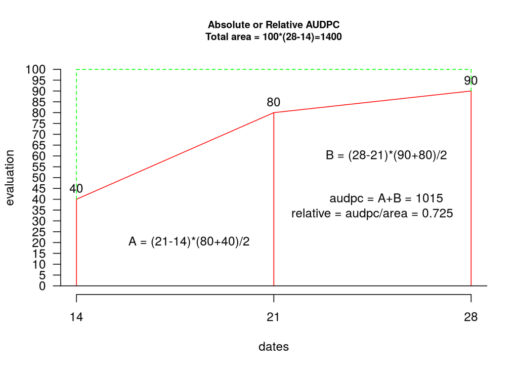

```
audpc> title(cex.main=0.8,main="Absolute or Relative AUDPC\nTotal area = 100*(28-14)=1400")

audpc> lines(dates,evaluation,col="red")

audpc> text(dates,evaluation+5,evaluation)

audpc> text(18,20,"A = (21-14)*(80+40)/2")

audpc> text(25,60,"B = (28-21)*(90+80)/2")

audpc> text(25,40,"audpc = A+B = 1015")

audpc> text(24.5,33,"relative = audpc/area = 0.725")

audpc> abline(h=0)

audpc> axis(1,dates)

audpc> axis(2,seq(0,100,5),las=2)

audpc> lines(rbind(c(14,40),c(14,100)),lty=8,col="green")

audpc> lines(rbind(c(14,100),c(28,100)),lty=8,col="green")

audpc> lines(rbind(c(28,90),c(28,100)),lty=8,col="green")

audpc> # It calculates audpc absolute
audpc> absolute<-audpc(evaluation,dates,type="absolute")

audpc> print(absolute)
[1] 1015

audpc> rm(evaluation, dates, absolute)

audpc> # example 3: evaluation dataframe nrow>1
audpc> data(disease)

audpc> dates<-c(1,2,3) # week

audpc> evaluation<-disease[,c(4,5,6)]
```

[output cut: 17 more lines]

```
audpc> data(CIC)

audpc> comas <- CIC$comas

audpc> oxapampa <- CIC$oxapampa

audpc> dcomas <- names(comas)[9:16]

audpc> days<- as.numeric(substr(dcomas,2,3))

audpc> AUDPC<- audpc(comas[,9:16],days)

audpc> relative<-audpc(comas[,9:16],days,type = "relative")

audpc> h1<-graph.freq(AUDPC,border="red",density=4,col="blue")
```

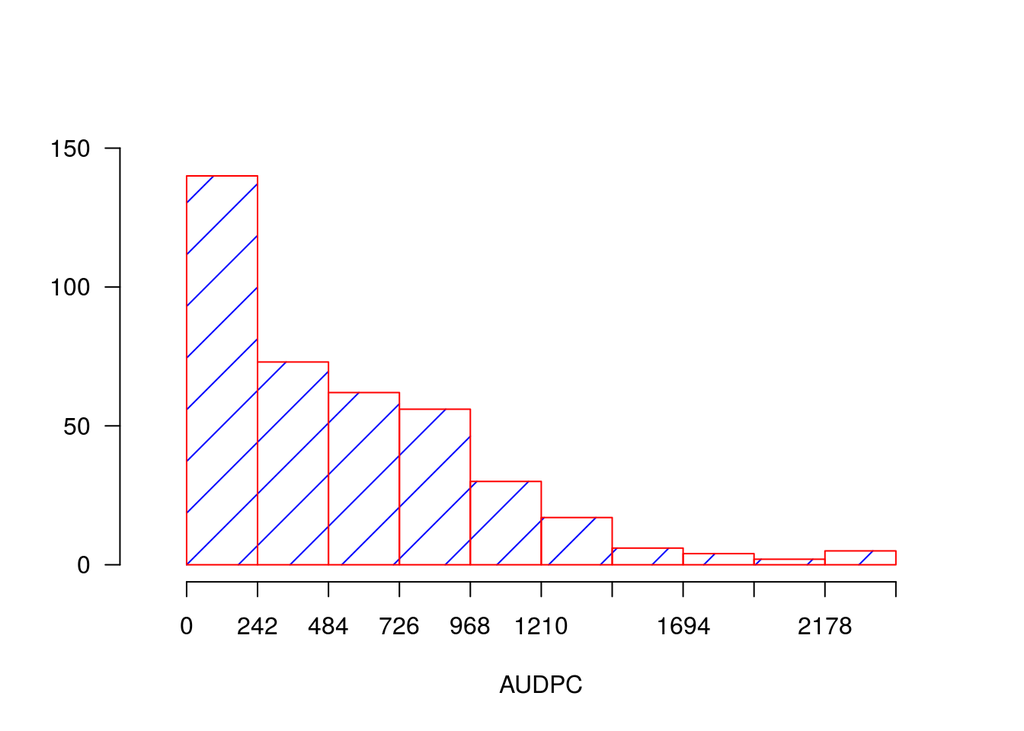

```
audpc> table.freq(h1)

audpc> h2<-graph.freq(relative,border="red",density=4,col="blue",
audpc+ frequency=2, ylab="relative frequency")
```

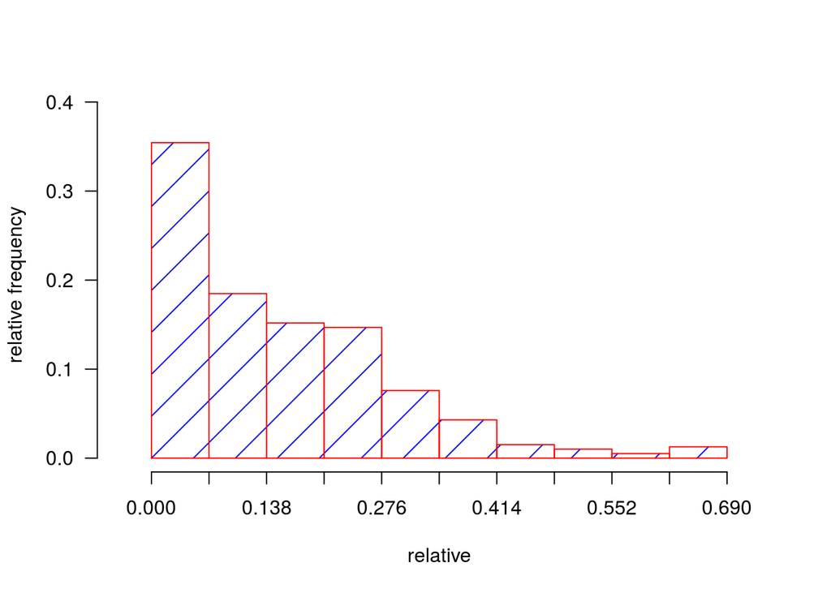

## Vignettes

Some packages include vignettes that can have different formats such as being introductions, tutorials, or reference cards in PDF format. You can look at a list of vignettes in all packages by typing:

```r
> browseVignettes()                  # see vignettes from all packages
> browseVignettes(package = "tidyr") # see vignettes from a specific package.
```

and to look at a specific vignette you can type:

```r
> vignette('mlg') # Multilocus Genotype vignette from the poppr package
```

# Glossary

**assignment operator (<-)**: assigns the result of whatever’s to the right of the operator to whatever is on the left

**data frame**: a representation of a table in R

**function**: a self-contained set of code that can be used many times

**functions**: a self-contained set of code that can be used many times

**packages**: a set of functions and data sets that are bundled together for distribution and download

**R library**: a folder/directory on your computer where your R packages are stored

**R prompt (>)**: a symbol that R uses to let you know it’s ready for you to enter commands

**vectors**: a sequence of data elements of the same type